# Google Data Analytics Captsone Project

## Key Insights

- The casual riders prefer longer trips than the member riders. But the members riders have a greater number of rides than the casual riders. This applies for months, seasons or days of the week.
- The average of the trip duration from the casual riders is more than twice than the member riders.
- The total % number of rides from the member riders is almost twice (with 64.33%) than the casual riders (with 35.67%)
- The visualizations above determine that the classic and electric bikes are the most favorite for both types of riders: casual and member. Almost the 50 and 50 percent are distributed among those two ride types.
- The busiest hour of the day for the use of bikes for members and casual riders is both at 17.
- Casual riders use cyclistic services more during the weekends, while members use them consistently over the entire week.
- Summer is the preferred time of the year for casual and member riders for using cyclistic services. Summer represents the 39% of use of bikes during the year.

### Some insights to visualize

```
## Defaulting to continuous.
```

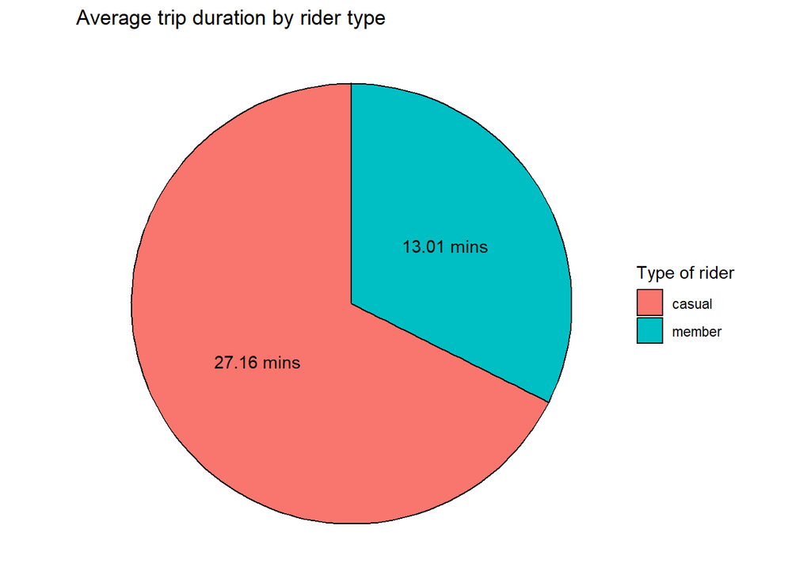

```r
calculations_member_casual %>%  ggplot(aes(x="", y=avg_ride_length, fill=member_casual)) +
  geom_col(color = "black") +
  ggtitle("Average trip duration by rider type") +
  theme(plot.title = element_text(hjust=0.5)) +
  labs(fill = "Type of rider") +
  geom_text(aes(label = str_c(round(avg_ride_length, digits = 2), " mins", sep = "")),
            position = position_stack(vjust = 0.5)) +
  coord_polar("y", start=0) +
  theme_void()
```

- In the visualization above we can determine that the average of the trip duration from the casual riders is more than twice than the member riders.

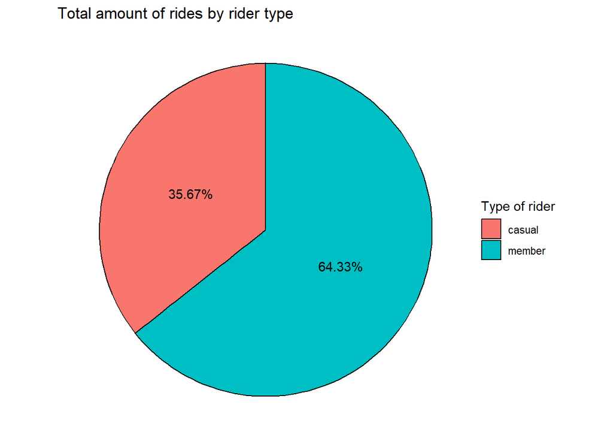

```r
calculations_member_casual %>%
  ggplot(aes(x="", y=num_of_rides, fill=member_casual)) +
  geom_col(color = "black") +
  ggtitle("Total amount of rides by rider type") +
  theme(plot.title = element_text(hjust=0.5)) +
  labs(fill = "Type of rider") +
  geom_text(aes(label = str_c(round((num_of_rides / sum(num_of_rides)) * 100, digits = 2), "%", sep = "")),
            position = position_stack(vjust = 0.5)) +
  coord_polar("y", start=0) +
  theme_void()
```

- In the visualization above we can determine that the total % amount of rides from the member riders is almost twice (with 64.33%) than the casual riders (with 35.67%).

## Recommendations

- Make an attractive promotion or year plan service that covers weekdays and another for weekends, both focused for casual riders so they can use the Cyclistic service across the entire week as they would like.
- Offer a discounted membership for new members in their first 3 months and a discounted membership fee for renewals after the first year.
- Provide an attractive promotio or year plan service that covers non-busy hours so casual riders could choose and use cyclistic services during the whole day.

**Note:** From the reccomendations above, I will suggest to make or start the promotions in the Summer season, where there are more people using the cyclistic service.

## Additonal data that could expand scope of analysis

- *Age of the rider*: The age would be really useful to know where and how can we focus the marketing and promotions plans for casual riders.
- *Gender of the rider*: As said in the point above, it would help on where and how can we focus the marketing and promotions plans for casual riders.
- *Surveys about acceptable price service*: Making surveys for casual riders to know what would it be an acceptable price for a membership or the reason to choose casual rides instead of membership.
- *Address of the rider*: Having the address of the rider at the moment they sign up in the app, could help to analyze if casual riders are having problems to access to close stations or we need to put more key stations close there.

## Resources

- [Stack Overflow](https://stackoverflow.com/)
- [R Documentation](https://www.rdocumentation.org/)
- [RStudio Posit Community](https://forum.posit.co/)